# TMDB movie data analysis

## by

# Shedrack David

## Overview

The Movie Database (TMDb) is a popular, user editable database for movies and TV shows.This data set contains information about 10,000 movies collected from The Movie Database (TMDb), including user ratings and revenue.

## Dataset Overview

There are about 10,000 movies collected from The Movie Database (TMDb) with features:

- id
- imdb_id
- popularity
- budget
- revenue
- original_title
- cast director
- overview
- runtime
- genres
- production_companies
- release_date
- vote_count
- vote_average
- release_year
- budget_adj
- revenue_adj
- vote_levels

## Properties associated with movies that have high revenues

### Popularity

During my investigation, popular movies tend to generate high revenue almost all the time. there is a strop positive relationship between popularity and revenue with very little outliers

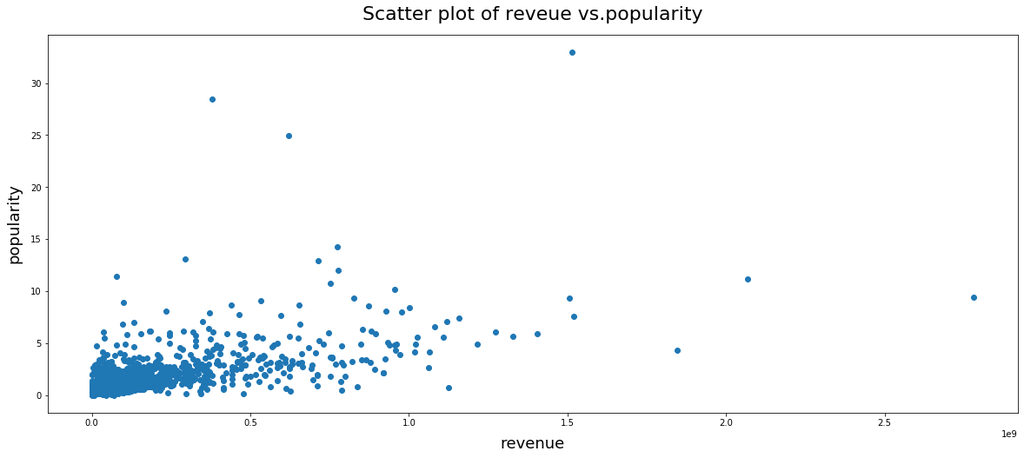

## Vote count

for the plot, i grouped the vote_labels with average revenue

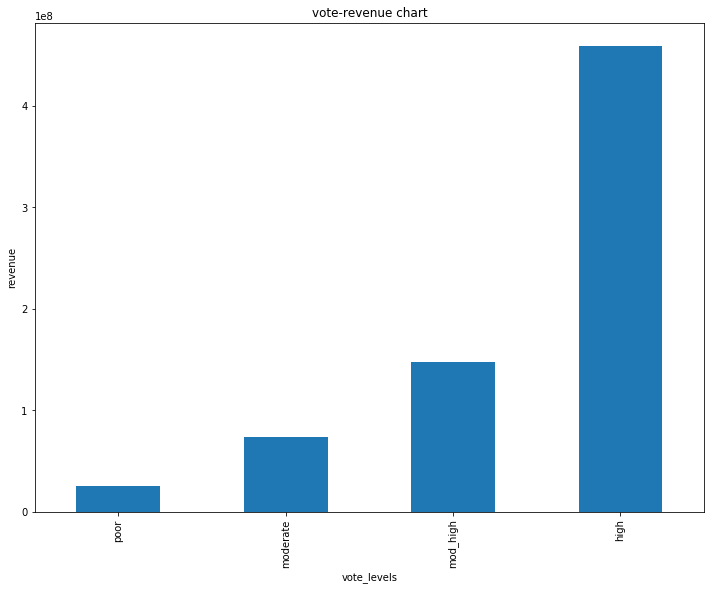

## Budget

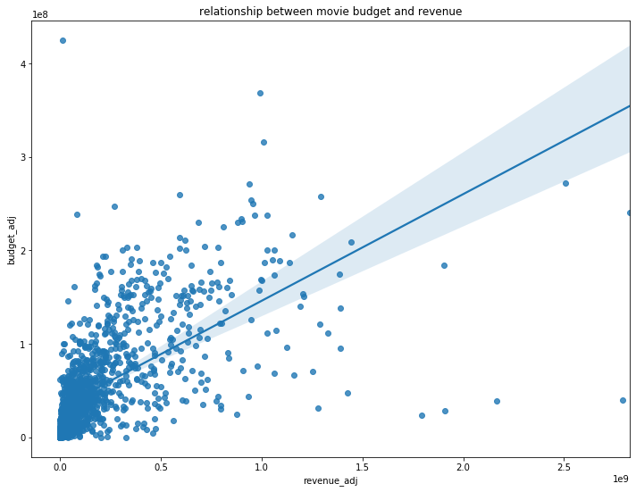

## Runtime

There is a slightly moderate strong correlation between revenue and runtime, so on average, movies that generated high revenue tend to have longer runtime.

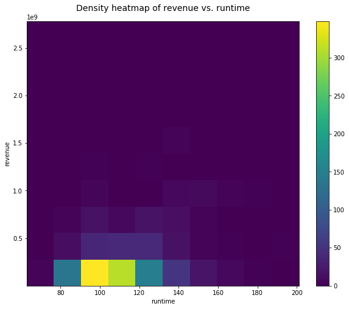

## most popular ,ovie genres from year to year

From what i observed, Adventure, Action, Science fiction and Thriller has been the the most popular genre of movie release from year to year since 1980. also, among the top 10 movie genres, "action" is the most popular and it appears even among a mix movie genre

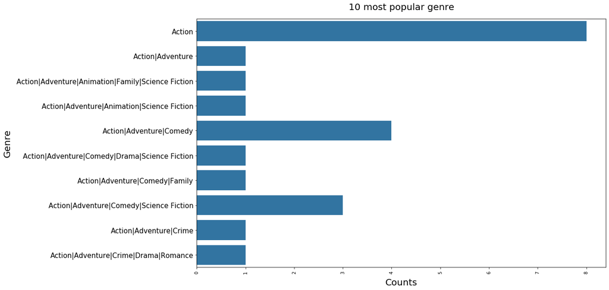

## Movie release per year

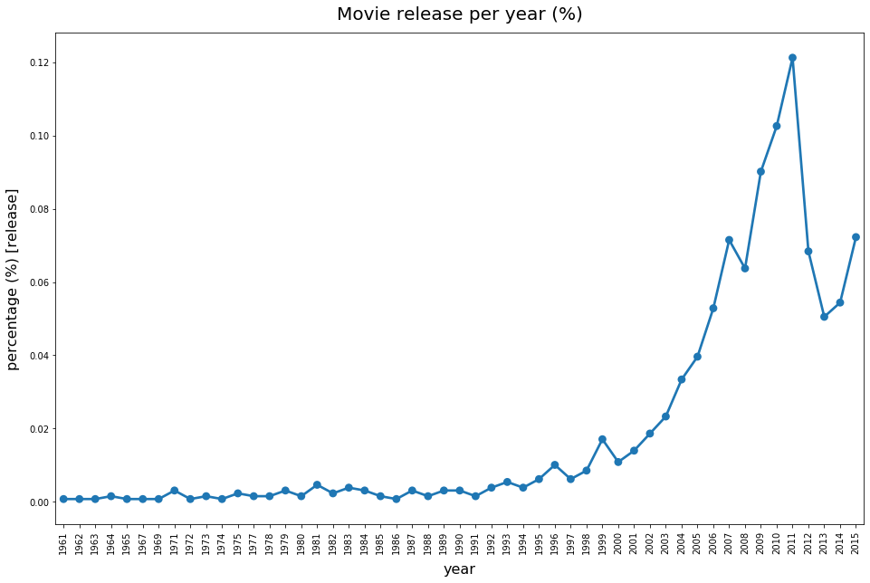

## Revenue, Runtime and vote vote count relationship

movies which had poor revenue had a high number of poor votes and it's runtime was shorter, the opposite is the case for movies which generated high revenue.

movies that have high revenue tend to be longer in and have no poor votes with very little people voting it as moderate.

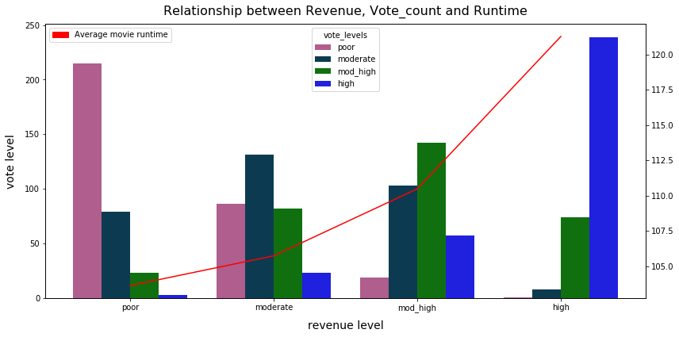